# Examen Parcial - Caso Airfares

**Equipo 05 - Escuadrón Europa**

- Linares Purizaca, Mauricio Javier 18200086
- Marcos de la Torre, Renzo Alexis 18200274
- Mejía Tarazona, Brandon Isaac 18200276
- Oroncuy Fernandez, Brayan Richard 18200282
- Ramos Paredes, Roger Anthony 18200096
- Salcedo Alfaron, Jhon Marco 18200101
- Vargas Pizango, Sebastian Enrique 18200104

La industria de las aerolíneas es un sector de rápido crecimiento, altamente competitivo y sujeto a cambios drásticos, incluso pequeños cambios en algunos parámetros críticos. Por lo tanto, aplicar el proceso de minería de datos a la toma de decisiones es muy crítico para una supervivencia y éxito más prolongados. Nuestro objetivo principal es implementar un modelo para una de las principales aerolíneas de los EE. UU., Para determinar si necesitan comenzar a operar hacia / desde los aeropuertos recientemente abiertos y cómo deberían fijar el precio de los vuelos en estas nuevas rutas. El análisis se basó en los datos históricos recopilados de una aerolínea en 638 rutas aéreas en los Estados Unidos.

```r
library('dplyr') # Funciones sencillas para realizar manipulación de datos en R
```

```r
library('corrplot') # Contiene varias funciones de utilidad básicos que incluyen: funciones estadísticas, de lectura / escritura, muestras, etc
library('caTools') # Visualización de datos en R
library('ggplot2') # Para trazar una matriz de correlación que muestre la relación entre cada variable.
library('caret') # Creación de variables ficticias para este caso.
library('rpart') # Se utiliza para crear modelos de árbol basados en regresión.
library('xgboost') # Se utiliza para crear modelos de impulso recién entrenados que aprenden de series anteriores de modelos y son eficientes, flexibles y portátiles
library('glmnet') # Se adapta a modelos lineales / modelos lineales generalizados que penalizan la probabilidad máxima, con regresión LASSO / Ridge
```

## Carga de datos

Cargando los datos del archivo csv. De forma predeterminada, las columnas como Tarifa, S_INCOME, etc. se han asignado como factores que deben convertirse en números. Además, dado que las columnas de cantidad están en formato de moneda del archivo de entrada, R las trata como valores no numéricos y, por lo tanto, es necesario eliminar la moneda y convertirla en formato de número.

```r
Airfare.data =  read.csv("Data.csv")
Airfare.data = Airfare.data[,-19]


dim(Airfare.data)  #638  18, es decir 638 filas y 18 columnas
```

```
## [1] 638  18
```

```r
str(Airfare.data)
```

```
## 'data.frame':    638 obs. of  18 variables:
##  $ S_CODE  : Factor w/ 8 levels "*","DCA","EWR",..: 1 1 1 8 7 1 1 1 1 1 ...
##  $ S_CITY  : Factor w/ 51 levels "Albuquerque         NM",..: 14 3 7 9 9 11 14 18 23 25 ...
##  $ E_CODE  : Factor w/ 8 levels "*","DCA","EWR",..: 1 1 1 1 1 1 1 1 1 1 ...
##  $ E_CITY  : Factor w/ 68 levels "Amarillo            TX",..: 1 2 2 2 2 2 2 2 2 2 ...
##  $ COUPON  : num  1 1.06 1.06 1.06 1.06 1.01 1.28 1.15 1.33 1.6 ...
##  $ NEW     : int  3 3 3 3 3 3 3 3 3 2 ...
##  $ VACATION: Factor w/ 2 levels "No","Yes": 1 1 1 1 1 1 1 2 1 1 ...
##  $ SW      : Factor w/ 2 levels "No","Yes": 2 1 1 2 2 2 1 2 2 2 ...
##  $ HI      : num  5292 5419 9185 2657 2657 ...
##  $ S_INCOME: Factor w/ 50 levels "$14,600","$18,933",..: 37 34 44 41 41 29 37 33 35 26 ...
##  $ E_INCOME: Factor w/ 67 levels "$14,600","$18,851",..: 7 57 57 57 57 57 57 57 57 57 ...
##  $ S_POP   : int  3036732 3532657 5787293 7830332 7830332 2230955 3036732 1440377 3770125 1694803 ...
##  $ E_POP   : int  205711 7145897 7145897 7145897 7145897 7145897 7145897 7145897 7145897 7145897 ...
##  $ SLOT    : Factor w/ 2 levels "Controlled","Free": 2 2 2 1 2 2 2 2 2 2 ...
##  $ GATE    : Factor w/ 2 levels "Constrained",..: 2 2 2 2 2 2 2 2 2 2 ...
##  $ DISTANCE: int  312 576 364 612 612 309 1220 921 1249 964 ...
##  $ PAX     : int  7864 8820 6452 25144 25144 13386 4625 5512 7811 4657 ...
##  $ FARE    : Factor w/ 451 levels "$100.36","$100.80",..: 371 170 219 427 427 345 241 48 168 41 ...
```

```r
Airfare.data$FARE = as.numeric(substr(as.character(Airfare.data$FARE),2,10)) # Para eliminar moneda $

## S_INCOME y E_INCOME son factores, necesitaremos convertirlo en número y eliminar el símbolo de moneda

Airfare.data$S_INCOME = as.numeric(gsub("\\$|,","",Airfare.data$S_INCOME))
Airfare.data$E_INCOME = as.numeric(gsub("\\$|,","",Airfare.data$E_INCOME))

Airfare = Airfare.data[,5:18]  # Eliminar las columnas no deseadas que tienen valores de texto

dim(Airfare)      # Obteniendo la dimensión (número de filas y columnas en nuestros datos)
```

```
## [1] 638  14
```

```r
summary(Airfare)   # Resumen de los datos
```

```
##      COUPON           NEW        VACATION    SW            HI
##  Min.   :1.000   Min.   :0.000   No :468   No :444   Min.   : 1230
##  1st Qu.:1.040   1st Qu.:3.000   Yes:170   Yes:194   1st Qu.: 3090
##  Median :1.150   Median :3.000                       Median : 4208
##  Mean   :1.202   Mean   :2.754                       Mean   : 4442
##  3rd Qu.:1.298   3rd Qu.:3.000                       3rd Qu.: 5481
##  Max.   :1.940   Max.   :3.000                       Max.   :10000
##     S_INCOME        E_INCOME         S_POP             E_POP
##  Min.   :14600   Min.   :14600   Min.   :  29838   Min.   : 111745
##  1st Qu.:24706   1st Qu.:23903   1st Qu.:1862106   1st Qu.:1228816
##  Median :28637   Median :26409   Median :3532657   Median :2195215
##  Mean   :27760   Mean   :27664   Mean   :4557004   Mean   :3194503
##  3rd Qu.:29694   3rd Qu.:31981   3rd Qu.:7830332   3rd Qu.:4549784
##  Max.   :38813   Max.   :38813   Max.   :9056076   Max.   :9056076
##          SLOT              GATE        DISTANCE           PAX
##  Controlled:182   Constrained:124   Min.   : 114.0   Min.   : 1504
##  Free      :456   Free       :514   1st Qu.: 455.0   1st Qu.: 5328
##                                     Median : 850.0   Median : 7792
##                                     Mean   : 975.7   Mean   :12782
##                                     3rd Qu.:1306.2   3rd Qu.:14090
##                                     Max.   :2764.0   Max.   :73892
##       FARE
##  Min.   : 42.47
##  1st Qu.:106.29
##  Median :144.60
##  Mean   :160.88
##  3rd Qu.:209.35
##  Max.   :402.02
```

## Análisis Exploratorio

Creación de una matriz de correlación, para encontrar la correlación entre las variables de entrada.

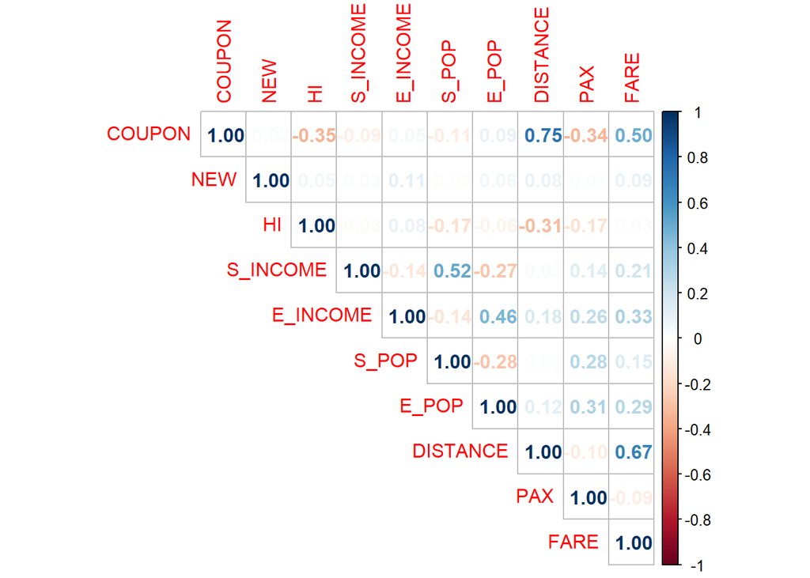

```r
Airfare.corr = select_if(Airfare, is.numeric) # seleccionando los que son numéricos
coorelation = corrplot(cor(Airfare.corr), type = "upper", method = "number")
```

En la gráfica, se puede ver que la `Distance` y `Coupon` tienen una correlación más positiva con nuestra variable a predecir `FARE`. Creamos plots individuales para observar los comportamientos:

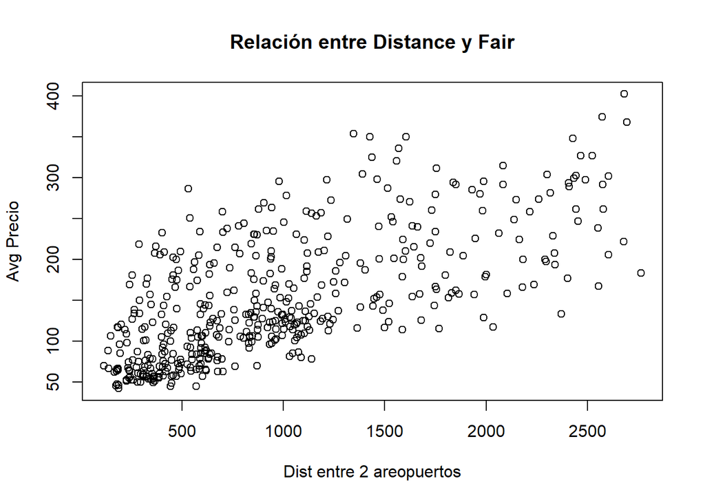

```r
plot(x = Airfare$DISTANCE, y = Airfare$FARE,type = "p", main = "Relación entre Distance y Fair", xlab = "Dist entre 2 areopuertos", ylab = "Avg Precio")
```

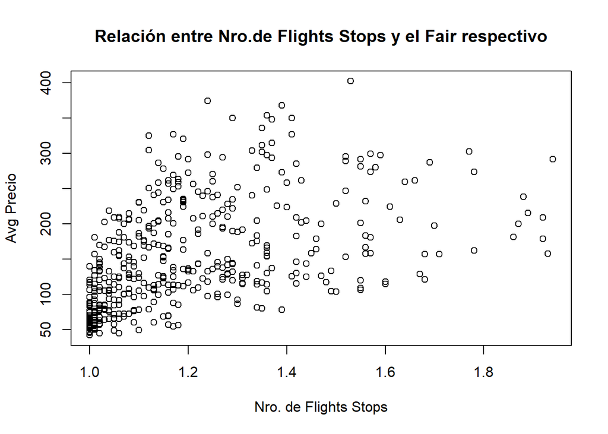

```r
plot(x = Airfare$COUPON, y = Airfare$FARE,type = "p", main = "Relación entre Nro.de Flights Stops y el Fair respectivo", xlab = "Nro. de Flights Stops", ylab = "Avg Precio")
```

## Preprocesamiento de datos

El preprocesamiento de datos consta principalmente de tres pasos:

1. Conversión de variables categóricas en variables dummy
2. Estandarizar o normalizar las columnas de datos, ya que algunas de las columnas como S_POP, E_INCOME tienen valores más altos en comparación con otras columnas como DISTANCE, SLOT, etc., por lo tanto, para eliminar el sesgo, tenemos que normalizar los datos.
3. Al dividir nuestro conjunto de datos en conjuntos de entrenamiento y prueba, la proporción de división es 80:20.

```r
# convertimos en variables dummy
DummyVar = dummyVars("~.",data = Airfare)
Airfare = data.frame(predict(DummyVar, newdata = Airfare))

# normalización
Airfare[,-18] <- lapply(Airfare[,-18], function(x) if(is.numeric(x)){(x - min(x))/(max(x) - min(x))} else x)

# DIVISIÓN DE DATOS EN CONJUNTOS DE ENTRENAMIENTO Y PRUEBAS
sampleSplit = sample.split(Airfare,SplitRatio = 0.8)
Airfare.training = subset(Airfare, sampleSplit == TRUE)
Airfare.test = subset(Airfare, sampleSplit == FALSE)
```

## Construccion de Modelos

El paso principal involucrado es desarrollar un modelo que pueda predecir efectivamente la tarifa aérea en función de las variables de entrada. El análisis se llevó a cabo utilizando cuatro modelos seleccionados, que fueron

- Modelo de regresión lineal múltiple
- Modelo de árbol de desición
- Modelo de aumento de gradiente extremo
- Modelo de regresión LASSO

### Regresión Lineal Múltiple

La regresión lineal múltiple es la forma más común de análisis de regresión lineal. Como análisis predictivo, la regresión lineal múltiple se utiliza para explicar la relación entre una variable dependiente continua y dos o más variables independientes. Aquí nuestra variable dependiente es la FARE.

```r
set.seed(100)
modelLr = lm(FARE ~., data = Airfare.training)
summary(modelLr)
```

```
##
## Call:
## lm(formula = FARE ~ ., data = Airfare.training)
##
## Residuals:
##      Min       1Q   Median       3Q      Max
## -106.039  -22.247   -2.691   20.566  126.653
##
## Coefficients: (4 not defined because of singularities)
##                  Estimate Std. Error t value Pr(>|t|)
## (Intercept)      -37.7906    10.8150  -3.494 0.000519 ***
## COUPON            -0.8823    13.4400  -0.066 0.947686
## NEW               -8.0664     6.0825  -1.326 0.185406
## VACATION.No       38.3973     4.0705   9.433  < 2e-16 ***
## VACATION.Yes           NA         NA      NA       NA
## SW.No             44.7428     4.3570  10.269  < 2e-16 ***
## SW.Yes                 NA         NA      NA       NA
## HI                71.4958     9.7509   7.332 9.58e-13 ***
## S_INCOME          24.2492    14.3281   1.692 0.091210 .
## E_INCOME          29.1050    10.3669   2.807 0.005195 **
## S_POP             30.7308     6.7400   4.559 6.50e-06 ***
## E_POP             38.0176     7.7828   4.885 1.41e-06 ***
## SLOT.Controlled   15.5647     4.3492   3.579 0.000380 ***
## SLOT.Free              NA         NA      NA       NA
## GATE.Constrained  19.9673     4.4940   4.443 1.10e-05 ***
## GATE.Free              NA         NA      NA       NA
## DISTANCE         202.0522    11.2305  17.991  < 2e-16 ***
## PAX              -67.2959    12.3998  -5.427 9.07e-08 ***
## ---
## Signif. codes:  0 '***' 0.001 '**' 0.01 '*' 0.05 '.' 0.1 ' ' 1
##
## Residual standard error: 35.87 on 484 degrees of freedom
## Multiple R-squared:  0.7924, Adjusted R-squared:  0.7868
## F-statistic: 142.1 on 13 and 484 DF,  p-value: < 2.2e-16
```

A partir del resultado, podemos ver que S_INCOME, COUPON, NEW son las menos significativas, por lo que se eliminan las variables basadas en valores significativos y luego se vuelve a ejecutar el modelo.

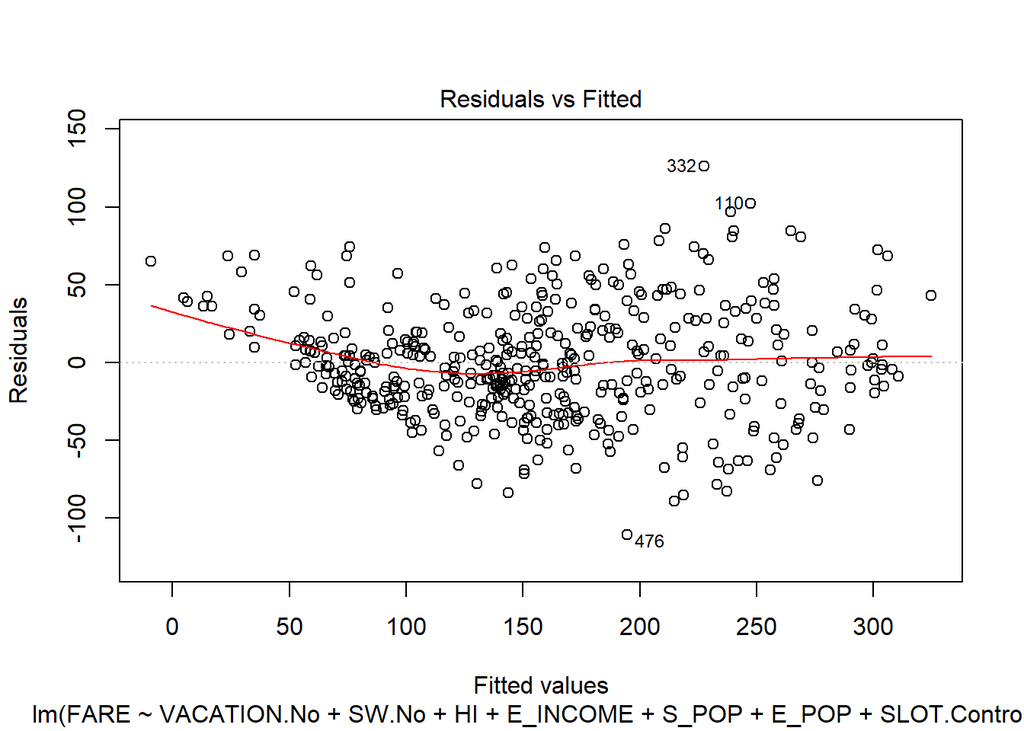

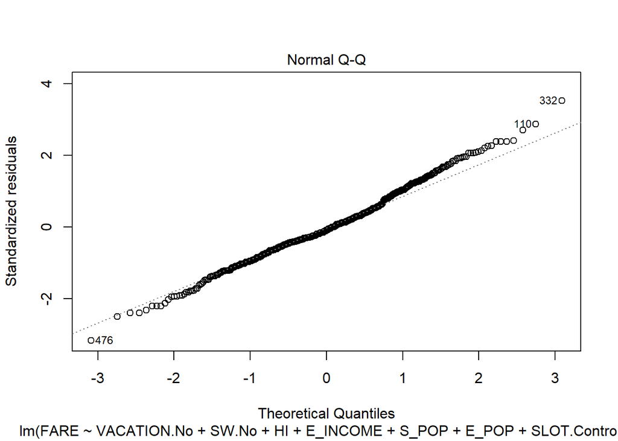

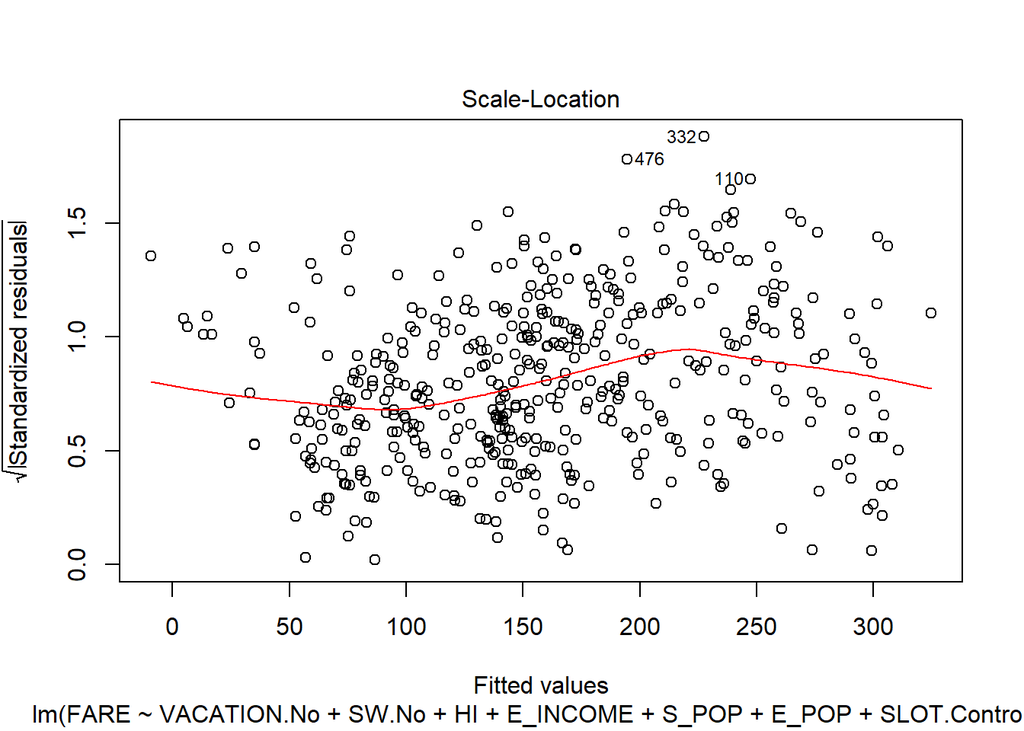

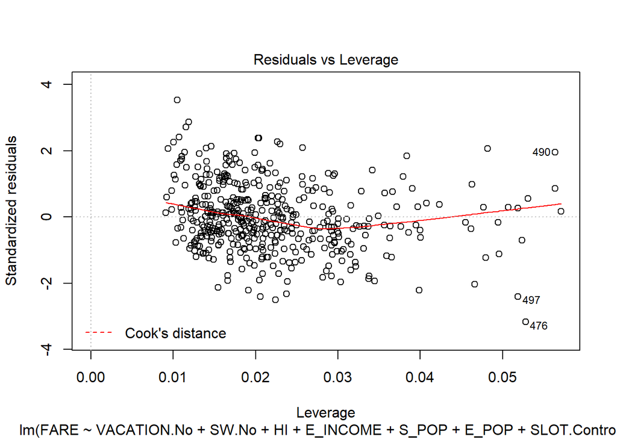

```r
set.seed(100)
modelLR = lm(FARE ~ VACATION.No+SW.No+HI+E_INCOME+S_POP+E_POP+SLOT.Controlled+GATE.Constrained+DISTANCE+PAX, data = Airfare.training)
LR.predict = predict(modelLR, newdata = Airfare.test[,-18])

## Calculamos el error cuadrático medio
AccuracyLR = sum(abs(LR.predict - Airfare.test[,18]))/length(Airfare.test[,18])

## Graficamos
plot(modelLR)
```

**ENTENDIENDO LAS GRAFICOS**:

### Arboles de Desición

El árbol de decisiones crea modelos de regresión o clasificación en forma de estructura de árbol. Divide un conjunto de datos en subconjuntos cada vez más pequeños mientras que, al mismo tiempo, se desarrolla de forma incremental un árbol de decisiones asociado. El resultado final es un árbol con nodos de decisión y nodos de hoja. Los árboles de decisión pueden manejar datos tanto categóricos como numéricos.

```r
set.seed(100)
modelDT = rpart(FARE ~.,data = Airfare.training)
DT.Predict = predict(modelDT, newdata = Airfare.test[,-18])

## Calculando el error cuadrático medio
AccuracyDT = sum(abs(DT.Predict - Airfare.test[,18]))/length(Airfare.test[,18])
```

### Aumento de Gradiente Extremo

El aumento de gradiente es un tipo de técnicas de conjunto en el aprendizaje automático supervisado, que intenta generar el resultado mediante la construcción de muchos modelos individuales, tratando de calcular la tasa de error (diferencia entre los valores reales y predichos), tratando de minimizar esta tasa de error. Boosting intenta construir muchos modelos individuales, considerando así la tasa de error del modelo anterior al siguiente para minimizarlo, y construyendo un modelo final fuerte combinando cada uno de estos modelos individuales.

```r
set.seed(100)

lab_matrix = as.matrix(Airfare.training$FARE)
data_trainX = as.matrix(Airfare.training[,-18])
dtrain = xgb.DMatrix(data = data_trainX, label = lab_matrix)
dim(as.matrix(Airfare.training$FARE))
```

```
## [1] 498   1
```

```r
dtest = xgb.DMatrix(data = as.matrix(Airfare.test[,-18]), label = as.matrix(Airfare.test$FARE))

# Definimos los parámetros
parameters = list(booster = "gblinear",
                  objective = "reg:linear",
                  eta = 0.1,           #Varía entre 0.1-0.3
                  nthread = 5,         #Aumente esto para mejorar la velocidad
                  max_depth = 15,
                  lambda= 0.5,         #Varía entre 0-3
                  alpha= 0.5,          #Varía entre 0-3
                  min_child_weight= 2, #Varía entre 1-10
                  eval_metric = "rmse")

model.Xgb = xgboost(params = parameters, data = dtrain, nrounds = 53)
```

[output not shown]

```r
model.Predict = predict(model.Xgb, dtest)

AccuracyXgb = sum(abs(model.Predict - Airfare.test[,18]))/length(Airfare.test[,18])
```

### LASO

LASSO - Operador de selección y contracción mínima absoluta es un método poderoso que realiza dos tareas principales: regularización y selección de características. El método LASSO intenta reducir la suma de los valores absolutos de los parámetros del modelo por debajo de un valor fijo (límite superior). Para ello, el método aplica un proceso de reducción (regularización) donde penaliza los coeficientes de las variables de regresión reduciendo algunas de ellas a cero. Las variables que todavía tienen un coeficiente distinto de cero después del proceso de contracción se seleccionan para formar parte del modelo. El objetivo de este proceso es minimizar el error de predicción.

Parámetro de ajuste lambda, controla la fuerza de la penalización. Cuanto mayor es el parámetro lambda, más coeficientes se reducen a cero. Por otro lado, si lambda = 0 tenemos una regresión OLS (Ordinary Least Sqaure). El valor de aplha elige entre los métodos LASSO y métodos de cresta (a = 1 LASSO, a = 0 Ridge Regularization). El eje x muestra diferentes valores del parámetro lambda. Cada línea representa una de las variables explicativas y su función en el modelo.

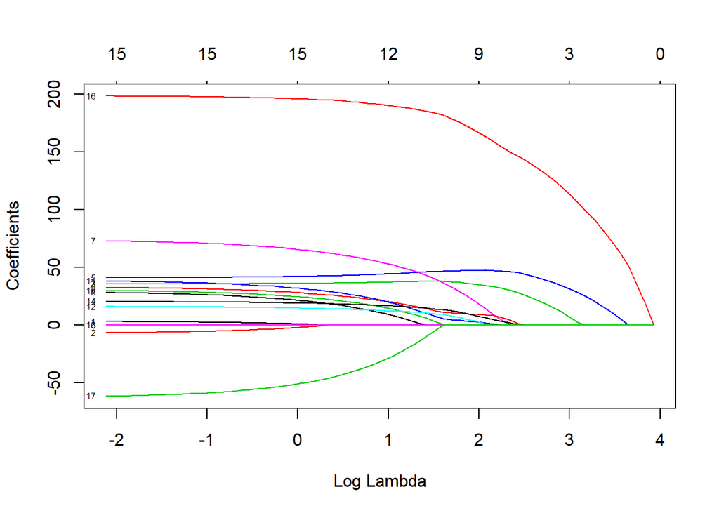

```r
set.seed(100)
# La entrada debe ser una matriz para aplicar LASSO
Airfare_X = as.matrix(Airfare[,-18])
Airfare_Y = Airfare$FARE
lasso_fit = glmnet(x = Airfare_X, y = Airfare_Y,family ="gaussian",alpha = 1 )

plot(lasso_fit, xvar = "lambda", label = TRUE)
```

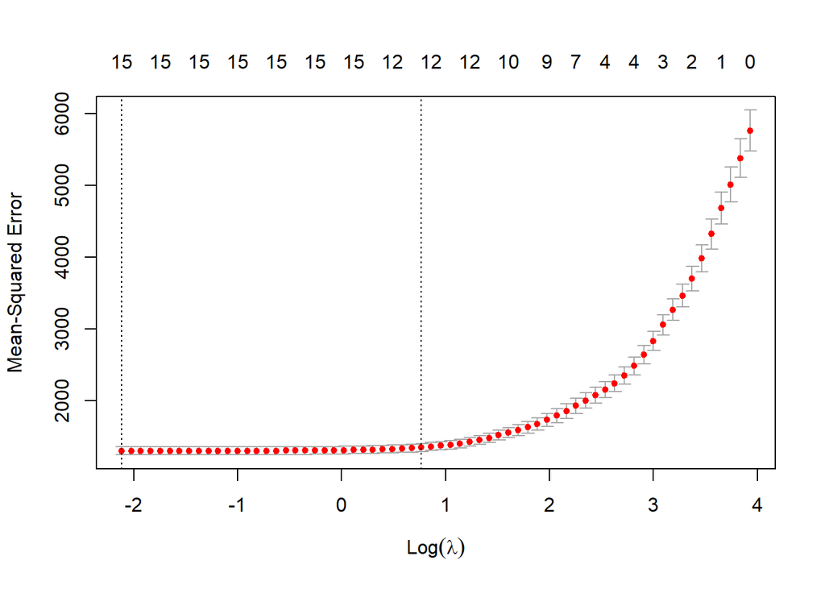

```r
# Validación cruzada para encontrar el valor de lambda
cv_lasso = cv.glmnet(x = Airfare_X, y = Airfare_Y, family = "gaussian", alpha = 1, nfolds = 10)
plot(cv_lasso)
```

```r
# Predecir el valor LASSO, tomando el valor mínimo de lambda
Lasso.Predict = predict(lasso_fit,newx = Airfare_X, s=cv_lasso$lambda.min)
# Precisión utilizando el primer método LASSO
AccuracyLS.min = sum(abs(Lasso.Predict - Airfare_Y))/length(Airfare_Y) #27.50271
# Predecir el valor LASSO, tomando el error estándar de lambda del mínimo
Lasso.Predict1se = predict(lasso_fit, newx = Airfare_X, s=cv_lasso$lambda.1se)
# Precisión con el segundo método LASSO
AccuracyLS.1se = sum(abs(Lasso.Predict1se - Airfare_Y))/length(Airfare_Y) #28.71035
```

## Resultados

El mejor mejor modelo encontrado fue el de regresión de LASSO debido a que obtuvo el menor error (27.50252) con respecto a los otros 3 modelos.

El objetivo principal del análisis fue construir un modelo de aprendizaje automático adecuado, que podría ayudar a SouthWest Airlines a predecir la tarifa aérea para una ruta más nueva.

```r
MACHINE_LEARNING_MODELS = c("Regresión Lineal Múltiple","Arbol de Desición","Aumento de Gradiente Extremo","Regresión de LASSO")
ERROR = c(AccuracyLR,AccuracyDT,AccuracyXgb,AccuracyLS.min)

df = data.frame(MACHINE_LEARNING_MODELS,ERROR)
df
```

```
##        MACHINE_LEARNING_MODELS    ERROR
## 1    Regresión Lineal Múltiple 27.62347
## 2            Arbol de Desición 30.08172
## 3 Aumento de Gradiente Extremo 43.99945
## 4           Regresión de LASSO 27.50252
```

A partir del análisis, se puede observar que la menor tasa de error se encontró utilizando el modelo de regresión LASSO, por lo que usamos ese modelo como nuestro análisis estándar para predecir las tarifas aéreas en la nueva ruta.

Las tasas de error de otros modelos, como la regresión lineal y los modelos de árbol, fueron lo suficientemente cercanas. El método XgBoost no predijo buenos resultados, puede deberse a que los conjuntos de datos de entrenamiento eran bajos.